# Avaliação Continuada - Aula 9

**Execute a célula a seguir para importar as bibliotecas de que vamos precisar e criar a variável `taxis` com nossa base de dados.**

```python
# Importando a biblioteca seaborn
import seaborn as sns
import matplotlib.pyplot as plt

# Carregando a base de dados 'taxis'
taxis = sns.load_dataset("taxis")

taxis["card_payment"] = taxis["payment"] == "credit card"

taxis.head()
```

|  | pickup | dropoff | passengers | distance | fare | tip | tolls | total | color | payment | pickup_zone | dropoff_zone | pickup_borough | dropoff_borough | card_payment |
| --- | --- | --- | --- | --- | --- | --- | --- | --- | --- | --- | --- | --- | --- | --- | --- |
| 0 | 2019-03-23 20:21:09 | 2019-03-23 20:27:24 | 1 | 1.60 | 7.0 | 2.15 | 0.0 | 12.95 | yellow | credit card | Lenox Hill West | UN/Turtle Bay South | Manhattan | Manhattan | True |
| 1 | 2019-03-04 16:11:55 | 2019-03-04 16:19:00 | 1 | 0.79 | 5.0 | 0.00 | 0.0 | 9.30 | yellow | cash | Upper West Side South | Upper West Side South | Manhattan | Manhattan | False |
| 2 | 2019-03-27 17:53:01 | 2019-03-27 18:00:25 | 1 | 1.37 | 7.5 | 2.36 | 0.0 | 14.16 | yellow | credit card | Alphabet City | West Village | Manhattan | Manhattan | True |
| 3 | 2019-03-10 01:23:59 | 2019-03-10 01:49:51 | 1 | 7.70 | 27.0 | 6.15 | 0.0 | 36.95 | yellow | credit card | Hudson Sq | Yorkville West | Manhattan | Manhattan | True |
| 4 | 2019-03-30 13:27:42 | 2019-03-30 13:37:14 | 3 | 2.16 | 9.0 | 1.10 | 0.0 | 13.40 | yellow | credit card | Midtown East | Yorkville West | Manhattan | Manhattan | True |

### Sobre os dados

No exercício de hoje, vamos utilizar as seguintes variáveis:

- `distance`: distância, em milhas, transcorrida na corrida.
- `total`: valor total pago pela corrida, incluindo o trajeto e a gorjeta, em dólares ($).

Nosso objetivo é verificar se há alguma relação entre essas variáveis.

### Exercício de hoje - Parte 1

No exercício de hoje estamos interessados em analisar apenas os táxis da cor verde. Esses, ao contrário dos amarelos, não podem começar a corrida em Manhattan.

Salve o resultado em uma variável chamada `green_taxis`.

```python
# continue o código abaixo
green_taxis = taxis
```

```python
# gabarito
green_taxis = taxis.query("color == 'green'")
```

**Observação sobre o gabarito:**

1. Há uma célula abaixo com o mesmo código. Ela deve ser desconsiderada na correção.

### Exercício de hoje - Parte 2

Seu trabalho hoje é modificar o gráfico abaixo explicando o achado de nossa análise.

Antes de executar as células abaixo você deve ter feito a parte 1 do exercício.

Vejamos primeiro esse gráfico:

```python
green_taxis = taxis.query("color == 'green'")
```

[output not shown]

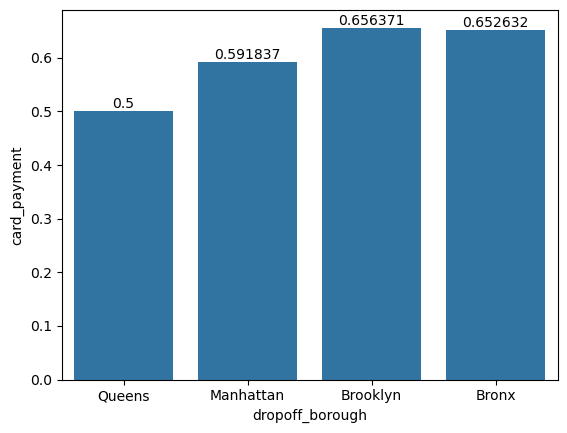

```python
fig, ax = plt.subplots()

sns.barplot(
    x="dropoff_borough",
    y="card_payment",
    data=green_taxis,
    errorbar=None,
    ax=ax,
)

ax.bar_label(ax.containers[0])
```

Aqui podemos observar a proporção de viagens que terminam em cada bairro pagas aos táxis verdes por cartão de crédito.

A região do Queens apresenta uma proporção consideravelmente menor de viagens pagas com cartão de crédito em comparação às demais regiões.

Vamos usar essa informação, mas sua tarefa vai ser alterar o gráfico abaixo sobre o valor médio das passagens encerradas em cada região:

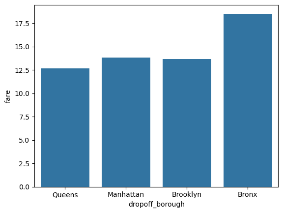

```python
sns.barplot(
    x="dropoff_borough",
    y="fare",
    data=green_taxis,
    errorbar=None,
)
```

Sua tarefa é modificar o código abaixo para:

1. Adicionar um título e alterar o rótulo dos eixos do gráfico, explicando a informação dessas barras.
2. Adicione o texto `"Viagens encerradas no Queens têm valor\nmais baixo e menor frequência de\npagamento em cartão de crédito!"` usando a função `plt.text` para adicionar essa informação no gráfico. Sugerimos colocar o texto na posição `x=0` e `y=15`.

```python
t = "Viagens encerradas no Queens têm valor\nmais baixo e menor frequência de\npagamento em cartão de crédito!"
```

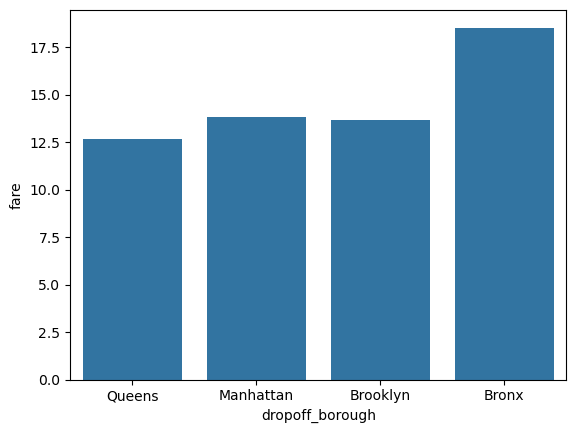

```python
fig, ax = plt.subplots()

sns.barplot(
    x="dropoff_borough",
    y="fare",
    data=green_taxis,
    errorbar=None,
    ax=ax,
)

# adicione seu código abaixo
```

**Gabarito**

1. O conteúdo do título e eixos não é importante, desde que tenham sido alterados explicitamente.
2. Ao adicionar o texto o aluno pode usar `s=t`, como abaixo, ou escrever o texto novamente.

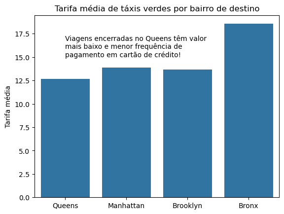

```python
fig, ax = plt.subplots()

sns.barplot(
    x="dropoff_borough",
    y="fare",
    data=green_taxis,
    errorbar=None,
    ax=ax,
)

# adicione seu código abaixo
ax.set_title("Tarifa média de táxis verdes por bairro de destino")
ax.set_ylabel("Tarifa média")
ax.set_xlabel("")

ax.text(
    s=t,
    x=0,
    y=15,
)
```